# Filtering for momentum strategy

## Trend

"The trend of a time series is considered to be the component containing the global change, which contrasts with local changes due to noise."

\[y_t = x_t + \epsilon_t\]

A filtering procedure consists of applying a filter \(\mathcal L\) to the data \(y\): \[\hat{x} = \mathcal L(y)\]

## Types of filter

1. Linear filter
   - Moving Average Filter
   - Moving Average Crossover
   - Least Square: L2 filter, Kalman filter
2. Nonlinear filter
   - Loess regression
   - L1 filter
   - Wavelet filter

## Assumption of price

We assume the price follows a lognormal distribution. \[\frac{d S_t}{S_t} = \mu_t \mathop{d}t + \sigma_t d W_t\]

Then we can define the return as:

\[R_t = \left(\ \mu_t - \frac{1}{2}\sigma_t^2 \right)\Delta + \sigma_t\sqrt{\Delta}\eta_t\] \(\mu_t\) is often regarded as the trend of price returns.

In this manner, we can easily convert between the trend of log-price and price returns.

## Moving Average Filter

In moving average filter, the filter function is defined as followed:

\[\mathcal L_i = \frac{1}{n}\mathbf{1}\left\{{i < n}\right\}\]

For the return, we have \[\hat{\mu}_t \simeq \frac{1}{\Delta}\sum_{i=0}^{n-1} \mathcal L_{i}R_{t-i}\]

## Simple moving average

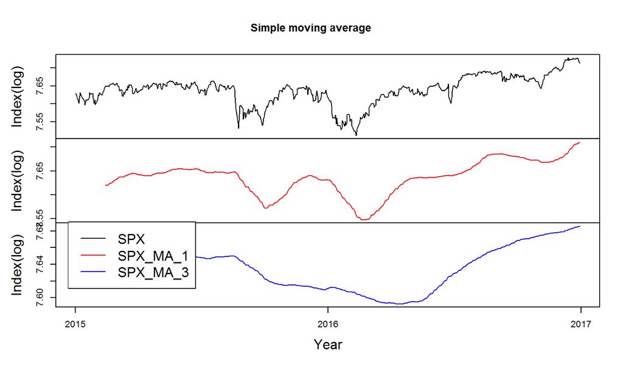

## L2 filter

We want to solve the function \[\left\{\hat{x}_1,...,\hat{x}_n\right\}=\arg\min\frac{1}{2}\sum_{t=1}^{n}\left(y_t-\hat{x}_t\right)^2\]

In practice, first we assume the trend of return is a constant. Then we will have the system: \[x_t = x_{t-1} + \mu\\y_t = \mu t + \epsilon_t\]

Then estimating the trend \(\hat{x}_t\) is also equivalent to estimating the coefficient \(\mu\) \[\hat{\mu}=\frac{\sum\nolimits_{t=1}^{n}ty_t}{\sum\nolimits_{t=1}^{n}t^2}\]

## L2 filter, cont'd 1

Then if we consider the \(\mu\) is not constant, we can define the following objective function, as a tradeoff between errors and smoothness. \[\frac{1}{2}\sum_{t=1}^{n}\left(y_t-\hat{x}_t\right)^2+\lambda\sum_{t=2}^{n-1}\left(\hat{x}_{t-1}-2\hat{x}_t+\hat{x}_{t+1}\right)^2\]

In vectorial form it is \[ \frac{1}{2}\left\lVert y-\hat{x} \right\rVert_2^2 + \lambda \left\lVert D\hat{x}\right\rVert_2^2\]

## L2 filter, cont'd 2

where \[D=\left( \begin{array}{cc} 1 & -2 & 1 & & & & &\\ & 1 & -2 & 1\\ & & & \ddots\\ &&&&1&-2&1\\ &&&&&1&2&1 \end{array}\right)\]

Then it can be rewritten as \[\hat{x}=\left(I+2\lambda D^TD\right)^{-1}y\]

## L2 filter, cont'd 3

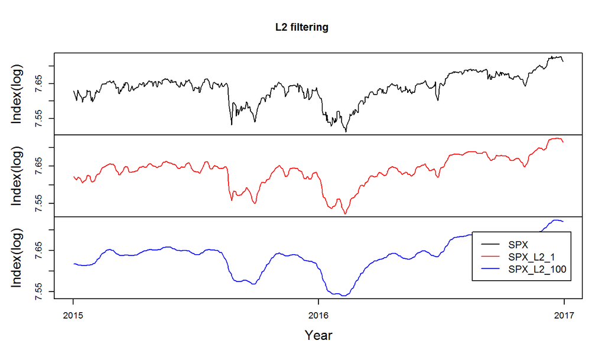

## Kalman filter

The dynamic of the system can be expressed as \[\begin{cases}R_t=\mu_t+\sigma_{\zeta}\zeta_t\\\mu_t=\mu_{t-1}+\sigma_{\eta}\eta_t\end{cases}\]

The estimation of \(\mu_t\) can be defined as \[\hat{\mu}_{t|t-1}=\mathbb{E}_{t-1}\left[\mu_t\right]\]

The variance of \(\mu_t\), \(P_t\) is defined as \[P_{t|t-1}=\mathbb{E}_{t-1}\left[\left(\hat{\mu}_{t|t-1}-\mu_t\right)^2\right]\]

## Kalman filter, cont'd 1

Therefore we can define that \[\hat{\mu}_{t+1|t}=(1-K_t)\hat{\mu}_{t|t-1}+K_tR_t\] in which \[K_t=\frac{P_{t|t-1}}{P_{t|t-1}+\sigma_{\zeta}^2}\]

In practice, one method of solving the equation is \[\hat{\mu}_{t+1|t}=(1-\kappa)\hat{\mu}_{t|t-1}+\kappa R_t\]

where\(\kappa=\frac{2\sigma_{\eta}}{\sigma_{\eta}+\sqrt{\sigma_{\eta}^2+4\sigma_{\zeta}^2}}\)

## Kalman filter, cont'd 2

If we wrote the formula as this, we can have \(\lambda =-\ln(1-\kappa)\)

Then the prediction of this single time series can be written as \[\hat{\mu}_t =\left(1-e^{-\lambda}\right)\sum_{i=0}^{\infty} e^{-\lambda i} R_{t-i}\] And the trend of log-price is \[\hat{x}_t = \left(1-e^{-\lambda}\right)\sum_{i=0}^{\infty} e^{-\lambda i}y_{t-i}\]

## Kalman Filter, cont'd 3

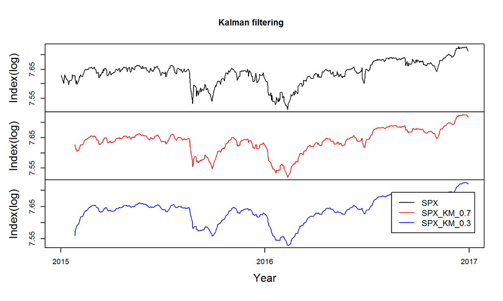

## Loess regression

For the local polynomial regression \[\begin{align}y_t & \,=\, f(t) \,+\, \epsilon_t \\& \,=\, \beta_0(\tau) \,+\, \sum_{j=1}^{p}\beta_j(\tau)(\tau \, - t)^j \,+\,\epsilon_t\ \\\end{align}\]

we use it to get the residuals \(\hat{\epsilon_t}\), then we compute \(\delta_t \,=\, (1 - \mu_t^2) \cdot 1\{|\mu_t|\leq 1\}\) with \(\mu_t = \hat{\epsilon}_t / (6\, \text{median}|\hat{\epsilon}|)\) and run a second kernel regression with weightings \(\delta_t w_t\)

## Loess regression, cont'd 1

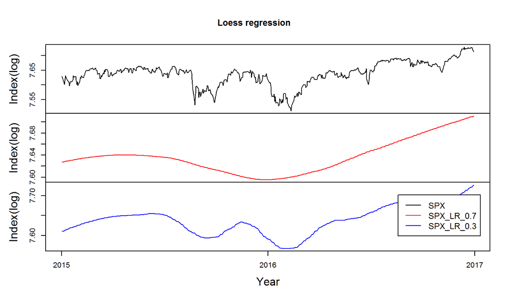

## L1 filter

Similar to the L2 filter, and much like the LASSO regression, we now consider the L1 term to be a smoothness penalty function. The objective function can then be written as \[\frac{1}{2} \sum_{t=1}^{n} \left(y_t - \hat{x}_t\right)^2 \,+\,\lambda \sum_{t=2}^{n-1}\left|\hat{x}_{t-1}-2\hat{x}_t+\hat{x}_{t+1}\right|\]

The equivalent vectorial form is \[\frac12 \left\lVert y-\hat{x} \right\rVert_2^2 \,+\,\lambda \left\lVert D\hat{x} \right\rVert_1 \]

## L1 filter, cont'd

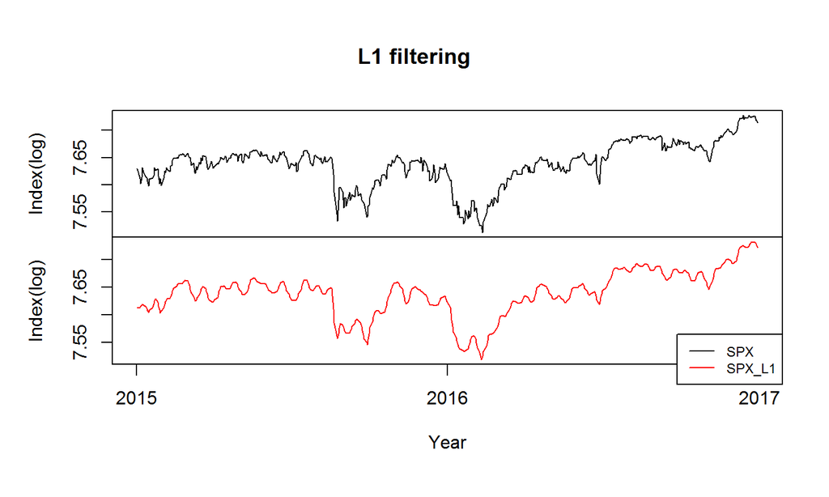

## Wavelet filter

The fourier transformation allows us to consider original signal as a combination of frequency functions \[y(\omega)=\sum_{t=1}^n y_t e^{-iwt} \]

To avoid difficulties when trend reverses, we will have Wavelet filter, which takes into consideration both frequency and time.

## Wavelet filter, cont'd 1

1. First we compute the wavelet transformation \(\mathcal W\) of \(y_t\) and get wavelet coefficients \(\omega = \mathcal W(y)\)
2. We apply a denoising rule \(D\): \[\omega^* = D(\omega)\]
3. Use the inverse Wavelet transformation \(\mathcal W^{-1}\) we get \[x=\mathcal W^{-1}\left(\omega^*\right)\]

## Wavelet filter, cont'd 2

The shrinkage methods includes: Let \(\omega^-\), \(\omega^+\) be two scalars with \(0<\omega^-<\omega^+\)

- Hard Shrinkage

\[\omega_i^* = \omega_i \cdot \mathbb{1}\left\{ \left|\omega_i\right| > \omega^+ \right\}\]

- Soft Shrinkage

\[\omega_i^* = \text{sgn}(\omega_i) \cdot \left( \left|\omega_i\right| - \omega^+ \right)_+ \]

- Semi-soft shrinkage

\[ \omega_i^* = \begin{cases} 0 & \, |\omega_i| \leq \omega^-\\ \text{sgn}(\omega_i)(\omega^+-\omega^-)^{-1}\omega^+(|\omega_i|-\omega^-) & \,\, \omega^-<|\omega_i| \leq \omega^+ \\ \omega_i & \, |\omega_i| > \omega^+ \end{cases}\]

- Quantile shrinkage is a hard shrinkage method where \(\omega^+\) is the \(q^{th}\) quantile of the coefficients \(|\omega_i|\)

## Wavelet filter, cont'd 3

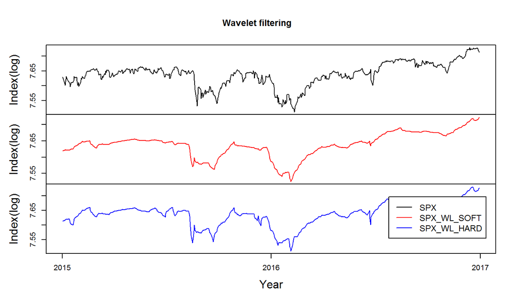

## Get the best parameter: Moving Average

The cross-validation gives little hint about moving average, since the shorter-term moving average almost surely closer to the actual data and produces less errors.

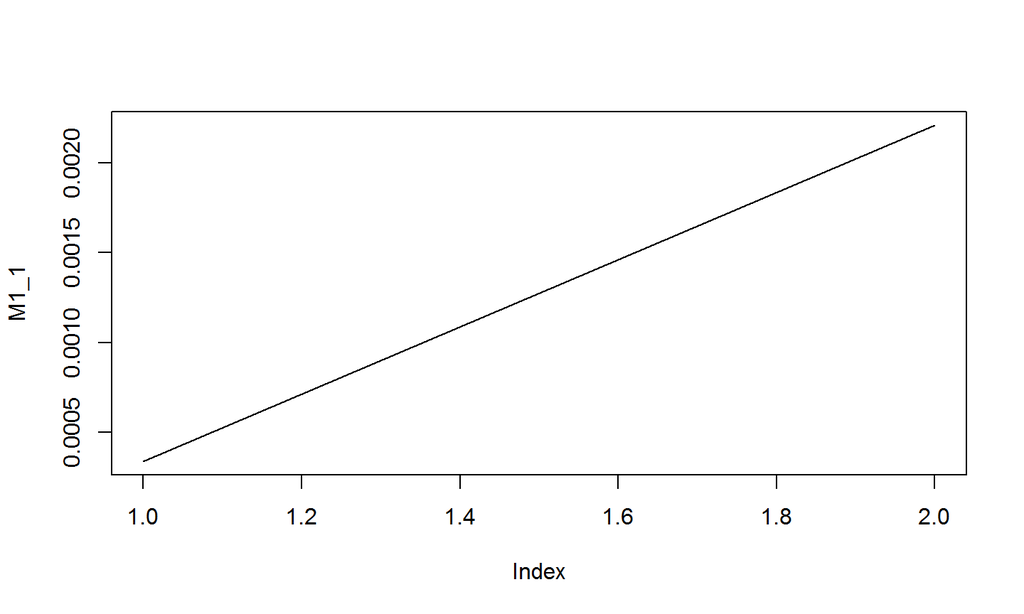

## Get the best parameter: L2

For L2 term we try to get the best lambda. The best lambda is therefore 0.06.

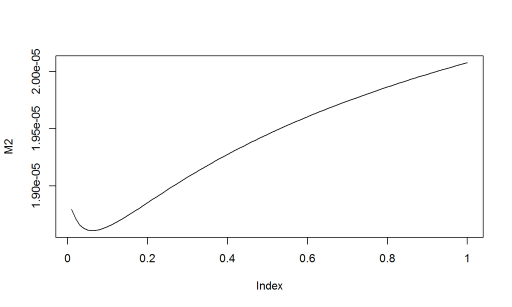

## Get the best parameter: Kalman filter

With Kalman filter we would like to get the best lambda through time series cross validation as well. In this case the optimal lambda value is 0.12.

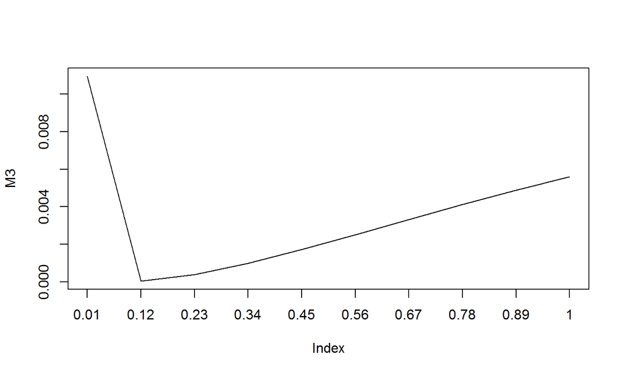

## Get the best parameter: Loess regression

In loess regression, the lambda controls degree of freedom for local polynomials. The lambda is set to 0.02.

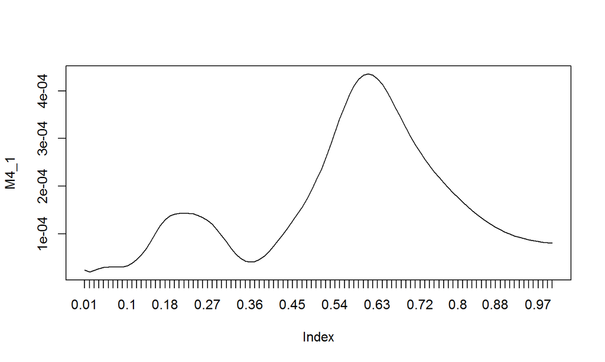

## Get the best parameter: L1 filter

For the L1 filter, it we set the error term to minimum, clearly lambda term should be minimum. In the following example, we choose 0.001 as the optimal lambda.

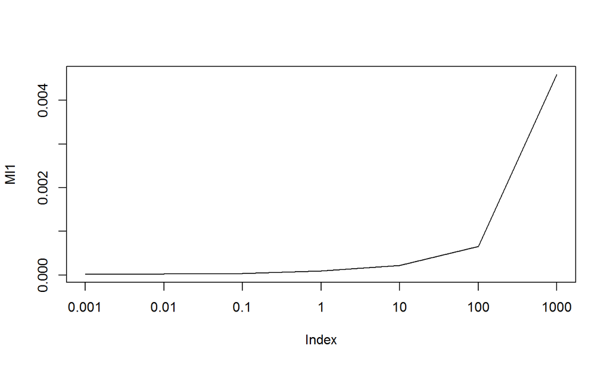

## Get the best parameter: Wavelet

For Wavelet transformation, we want to make sure which kind of shrinkage methods yields the best trends for prediction.

Based on the findings below, we choose the "soft" threshold.

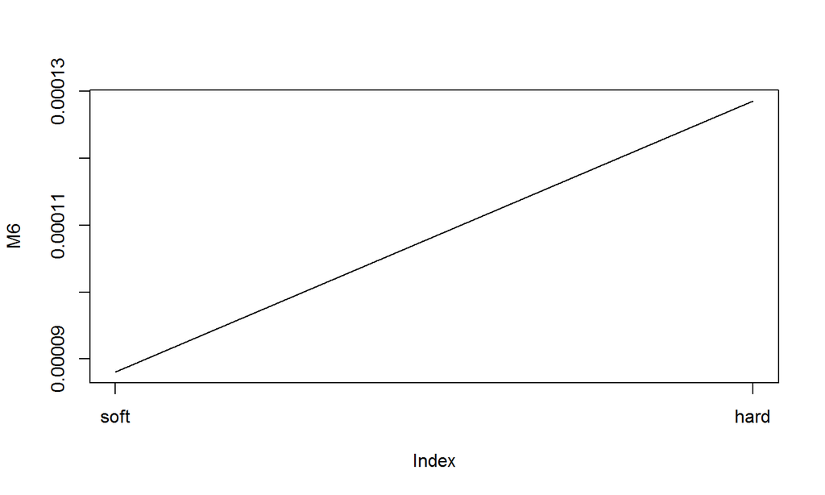

## Trading strategy based on trend

|  | hits | dayswin | dayslose | win | lose |
| --- | --- | --- | --- | --- | --- |
| L2 | 0.4648829 | 139 | 159 | 0.0052220 | -0.0055029 |
| Kalman | 0.5317726 | 159 | 139 | 0.0055029 | -0.0052220 |
| Loess | 0.5317726 | 159 | 139 | 0.0049770 | -0.0058237 |
| L1 | 0.4381271 | 131 | 167 | 0.0054572 | -0.0053050 |
| Wavelet | 0.5284281 | 158 | 140 | 0.0054886 | -0.0052402 |

## Refrences

[1] TREND FILTERING METHODS FOR MOMENTUM STRATEGIES, Benjamin Bruder et al, Lyxor Asset Management

[2] Understanding Extended Kalman Filter – Part II: Multi-dimensional Kalman Filter, Shudong Huang, University of Technology Sydney

[3] Wavelet Methods in Statistics with R, Guy Nason